# Do Outdoor Green Educational Activities Make a Difference for Teachers?

A Re-Analysis through Data Visualization and the Overlapping Index

A. Perugini, M. Pastore, O. Mosca,  
E. Rubat du Mérac, F. Fornara

Conference of Environmental Psychology 18 - 19 November 2026 | Lillehammer

## The Problem

Data in psychology:

- is often not normally distributed
- does not respect parametric tests assumptions (i.e. t-test)
- is made of small samples

Therefore:

- differences beyond mean are overlooked
- higher chances of type I and type II errors
- studies are under-powered

## An extreme example

$n = 30$ x group, $m_{y1}=10.03$ and $m_{y2}=9.86$

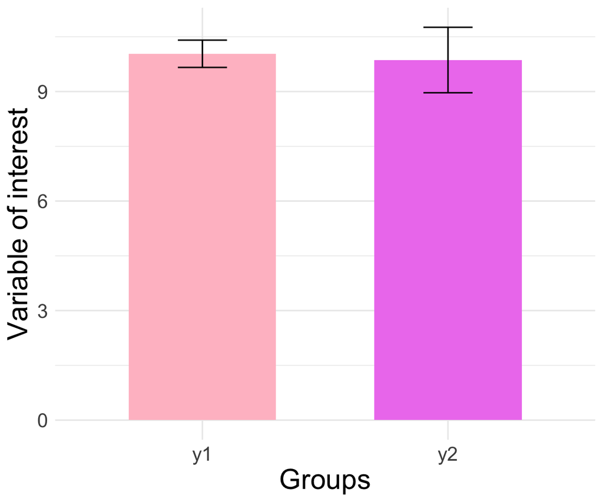

## An extreme example

$n = 30$ x group, $m_{y1}=10.03$ and $m_{y2}=9.86$

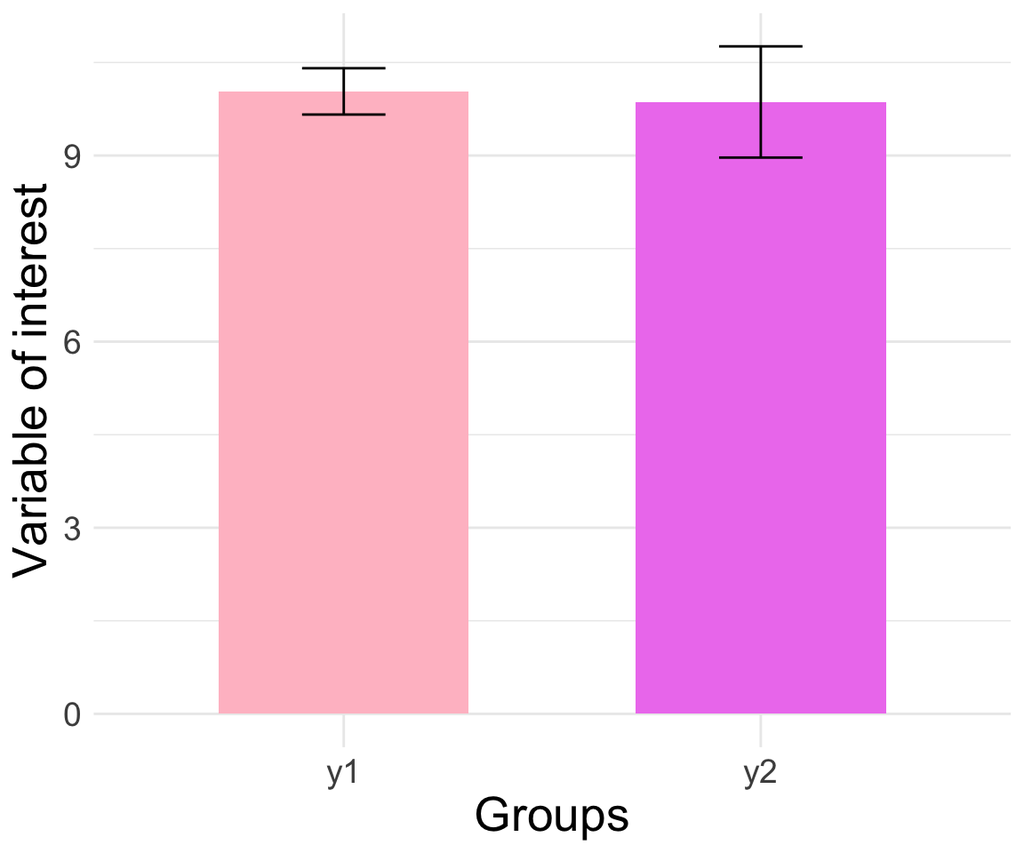

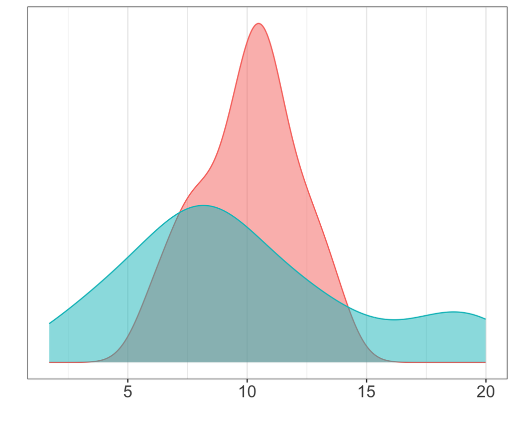

## Possible solutions

- Use descriptive statistics
- Test hypothesis only if appropriate
- Use statistics that respect the nature of the data (i.e. non-parametric tests)

[figure not shown]

## The Overlapping Index

The Overlapping Index ($\eta$) is an index of **effect size** and varies from 0 and 1.

The Index calculates the area of overlap between two or more **groups/conditions**.

- 0 – there are no points in common
- 1 – there is complete overlap

## Permutation test

- Usually $H_0 = 0$ and $H_1 \neq 0$
- The Overlapping Test is defined as $1 - \eta = \zeta$
- So $H_0 : \zeta = 0$ (no difference between groups)

The permutation test:

- Shuffles the data $B$ times
- Calculates the statistic for each new dataset of permuted data
- Calculates $p$- value as the probability of obtaining equal or more extreme values

# Application on real data

## The study

**AIM** – Compare Outdoor and Indoor teachers on:

- Affective qualities of school places (Revised School-Level Environment Questionnaire - R-SLEQ)
- Psychological distress (Depression Anxiety Stress Scale - DASS-21)
- Life satisfaction (Satisfaction with life - SWLS)

**Hypothesis** – Outdoor teachers report:

- More favorable organizational climate (R-SLEQ)
- No differences in psychological distress (DASS-21)
- No differences in life satisfaction (SWLS)

## Sample characteristics

- 136 Italian teachers (96.3% women), mean age = 45.16 years ($SD = 10.64$, range $24-64$)
- Outdoor teachers: n = 81
- Indoor teachers: n = 55
- 66.9% primary, 31.6% kindergarten, 1.5% lower secondary school

## Analysis workflow

1. Data visualization and Descriptive statistics
2. Significance Testing
3. Tailored specific parametric testing

[figure not shown]

# Results R-SLEQ

## STEP 1:

**Data visualization and Descriptive statistics**

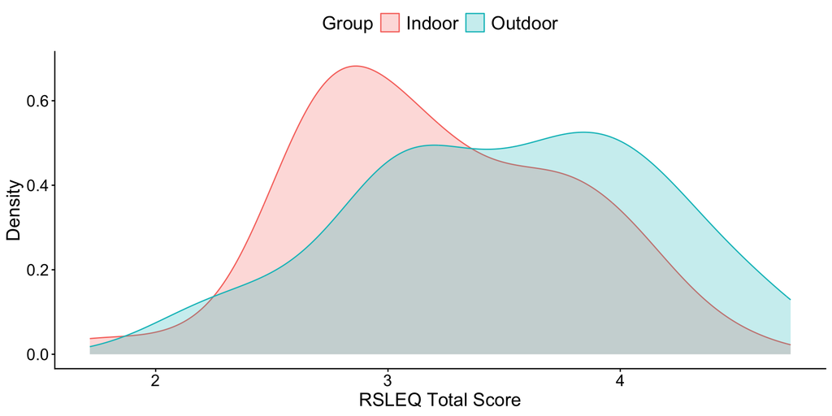

## STEP 1:

**Data visualization and Descriptive statistics**

| Group | N | Mean | SD | Skewness | Kurtosis |
| --- | --- | --- | --- | --- | --- |
| Indoor | 55 | 3.202 | 0.572 | 0.085 | -0.460 |
| Outdoor | 81 | 3.507 | 0.646 | -0.214 | -0.696 |

```r
library(overlapping)
overlap(List_RSLEQ, plot = F)
```

```
$OV
[1] 0.8043936
```

## STEP 2:

**Significance Testing**

```r
perm.test(List_RSLEQ, paired = F, B = 1000, return.distribution = F)
```

```
$Zobs
[1] 0.1956064

$pval
[1] 0.02497502
```

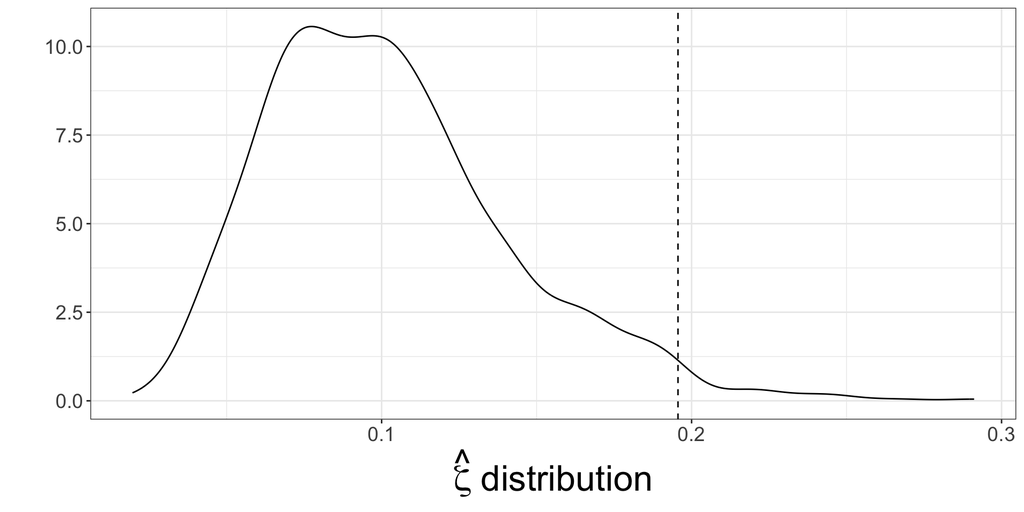

## STEP 3:

**Tailored specific parametric testing**

One Way Anova: $F(1, 134) = 7.98$, $p = 0.006$

**Assumption of Normality Check**

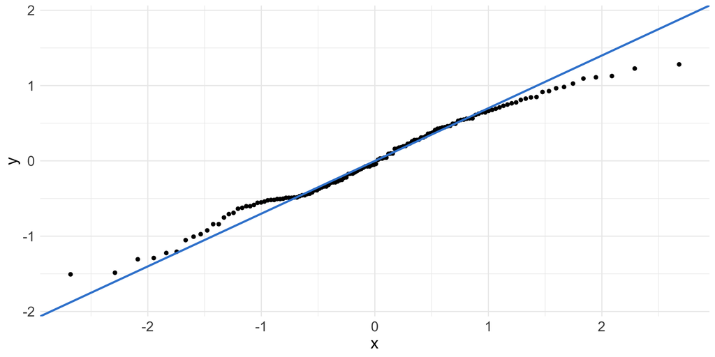

# Results DASS

## STEP 1:

**Data visualization and Descriptive statistics**

[figure not shown]

## STEP 1:

**Data visualization and Descriptive statistics**

| Group | N | Mean | SD | Skewness | Kurtosis |
| --- | --- | --- | --- | --- | --- |
| Indoor | 55 | 0.700 | 0.499 | 0.672 | -0.443 |
| Outdoor | 81 | 0.725 | 0.580 | 0.869 | 0.408 |

```r
library(overlapping)
overlap(List_DASS, plot=F)
```

```
$OV
[1] 0.9128611
```

## STEP 2:

**Significance Testing**

```r
perm.test(List_DASS, paired = F, B = 1000, return.distribution = F)
```

```
$Zobs
[1] 0.08713891

$pval
[1] 0.5534466
```

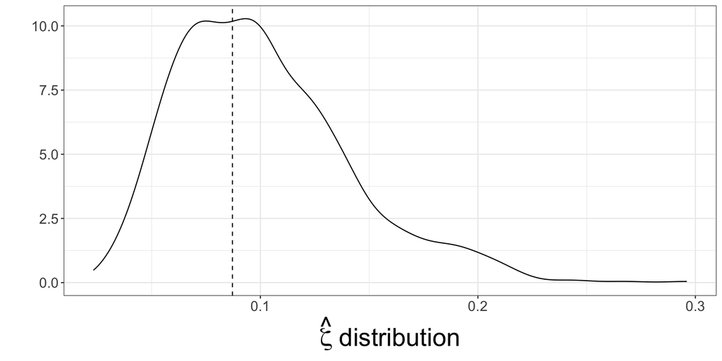

## STEP 3:

**Tailored specific parametric testing**

One Way Anova: $F(1, 134) = 0.07$, $p = 0.79$

**Assumption of Normality Check**

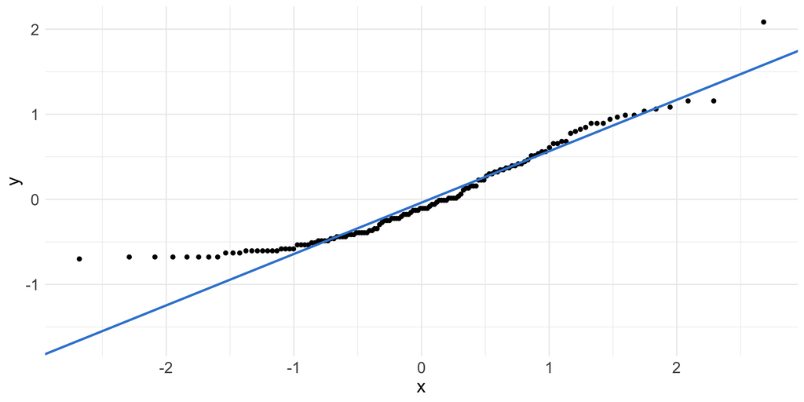

# Results SWLS

## STEP 1:

**Data visualization and Descriptive statistics**

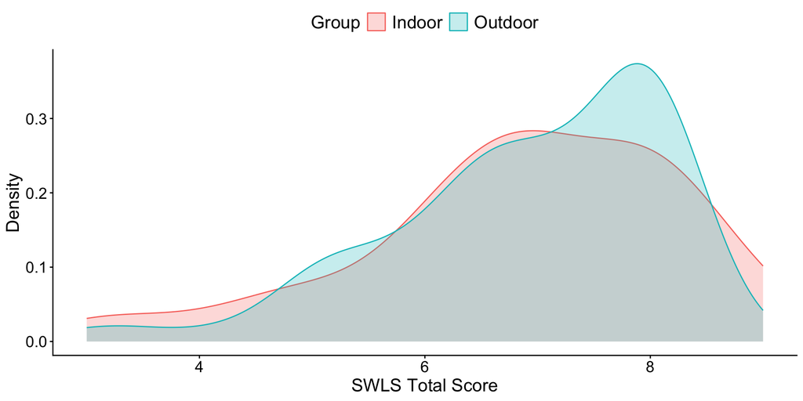

## STEP 1:

**Data visualization and Descriptive statistics**

| Group | N | Mean | SD | Skewness | Kurtosis |
| --- | --- | --- | --- | --- | --- |
| Indoor | 55 | 6.855 | 1.402 | -0.810 | 0.278 |
| Outdoor | 81 | 6.923 | 1.202 | -0.999 | 0.601 |

```r
library(overlapping)
overlap(List_SWLS, plot=F)
```

```
$OV
[1] 0.9138202
```

## STEP 2:

**Significance Testing**

```r
perm.test(List_SWLS, paired = F, B = 1000, return.distribution = F)
```

```
$Zobs
[1] 0.08617982

$pval
[1] 0.6143856
```

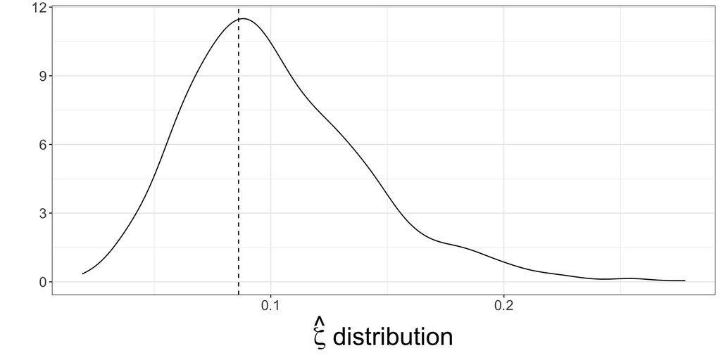

## STEP 3:

**Tailored specific parametric testing**

One Way Anova: $F(1, 134) = 0.09$, $p = 0.76$

**Assumption of Normality Check**

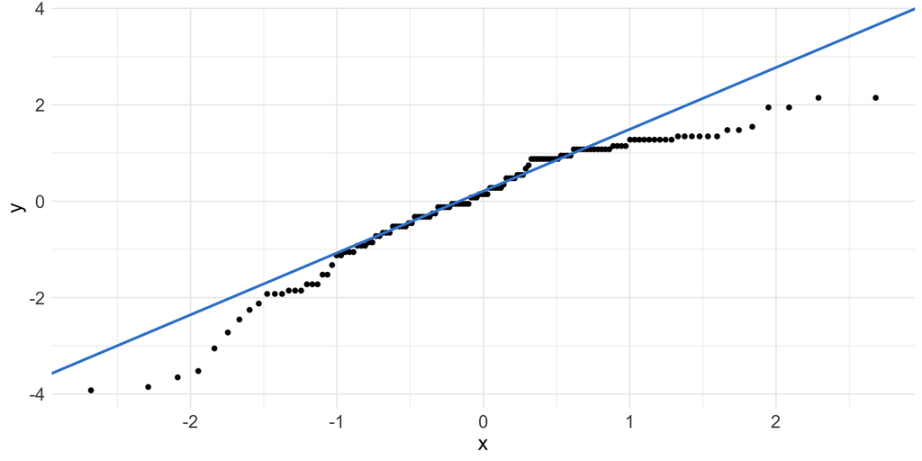

## To Conclude

- Outdoor teachers reported more positive affective qualities of school places
- No differences were detected for Psychological Distress and Life Satisfaction

[figure not shown]

## Take home message

- Always plot your data BEFORE running the analysis
- Be aware of parametric tests assumptions
- Thinking Before Testing (cit. Richard McElreath )
- Collaboration is key

[figure not shown]

## To find out more:

Here you can find our manuscript, on the implementation of the permutation test for the overlapping index:

https://doi.org/10.3758/s13423-026-02946-z

[figure not shown]

[figure not shown]

ambra.perugini@phd.unipd.it